# How to Use the INVENT Package

Davide Fabbrico

2025-03-05

## Introduction

This file contains the documentation for the R package INVENT. The documentation is organized as follows:

- **Chapter 1**: Shows how to install the package and provides an initial overview of its usage, including an example of using a function to generate synthetic data.
- **Chapter 2**: Offers a detailed description of the input parameters for the main algorithm and the function used for generating synthetic data.
- **Chapter 3**: Presents a practical application on a real dataset.

## How to Install the Package

First, if you haven’t already installed the devtools package, you can do so using the command in line 1. Once installed, you can proceed to install the `INVENT` package directly from my GitHub repository using the command in line 2.

```r
# install.packages("devtools")
devtools::install_github("davidefabbrico/invent", force = TRUE)
```

Now that the package is installed, let’s walk through a simple example. We will generate synthetic data and run the model using the invMCMC function.

```r
# Load the R package
library(invent)

# Set Seed
set.seed(10)

# Generate synthetic data
data_list <- invent::gendata(n_obs = 400, p = 10, scenario = 4)

# response vector
y <- data_list$Y
# design matrix
x <- data_list$X

# Run the regression model
out <- invent::invMCMC(y, x, iter = 10000, burnin = 5000, thin = 5, ha = 2,
                       data = data_list, detail = TRUE, pb = TRUE)
```

## `gendata` function

In this section, we demonstrate how to use the `gendata` function to generate synthetic data for the various scenarios described in the manuscript. The `gendata` function requires the following input parameters:

- **`n_obs`**: The number of observations.
- **`p`**: The number of covariates.
- **`minb`**: The minimum value for the coefficients.
- **`maxb`**: The maximum value for the coefficients.
- **`error`**: The standard deviation component of the model error.
- **`scenario`**: The scenario number to generate:
  - **Scenario 1**: Linear main effects and linear interactions.
  - **Scenario 2**: Linear main effects and non-linear interactions.
  - **Scenario 3**: Non-linear main effects and linear interactions.
  - **Scenario 4**: Non-linear main effects and non-linear interactions.
- **`nnnc`**: The number of non-zero covariates.
- **`noi`**: The number of non-zero interactions for each non-zero main effect.
- **`ha`**: The heredity assumption:
  - `ha = 2`: **Strong heredity assumption** → An interaction effect is present only if both main effects are present.
  - `ha = 1`: **Weak heredity assumption** → An interaction effect is present if at least one of the main effects is present.
  - `ha = 0`: **No heredity assumption** → Main and interaction effects are independent.

The data generating mechanism `gendata` uses the following default input parameters:

```r
# Generate synthetic data for scenario 4
data_list <- invent::gendata(n_obs = 200, p = 10, minb = 1.5, maxb = 3.0, error = 0.01,
                    scenario = 4, nnnc = 3, noi = 3, ha = 2)
```

## `invMCMC` function

### Input Parameters Description

The `invMCMC` function requires several input parameters. Below is a detailed description of each parameter:

- **`y`**: A vector containing the observed data (dependent variable) for the training set.
- **`x`**: A matrix containing the values of the covariates for each observation in the training set.
- **`y_val`**: A vector containing the observed data (dependent variable) for the validation set.
- **`x_val`**: A matrix containing the values of the covariates for each observation in the validation set.
- **`hyperpar`**: A vector of hyperparameters defining the prior distribution for the model parameters.
- **`mht`**: A vector containing Metropolis-Hastings-related parameters for proposing new values during sampling.
- **`rank`**: The percentage of data variability explained by the **P-spline**.
- **`iter`**: The total number of iterations for the MCMC sampling process.
- **`burnin`**: The number of initial iterations to discard during the burn-in period.
- **`thin`**: The thinning interval, specifying how often to retain a sample.
- **`ha`**: The heredity assumption for the model, potentially defining relationships between variables.
- **`detail`**: A boolean flag indicating whether to retain all MCMC chain samples.
- **`data`**: If a synthetic dataset is provided, the algorithm computes metrics for covariate selection (TPR, FPR, and MCC).
- **`pb`**: A boolean flag specifying whether to display a progress bar during sampling.

The algorithm uses the following default input parameters:

```r
out <- invMCMC(y, x, y_val = NULL, x_val = NULL,
               hyperpar = c(3, 1, 1, 1, 0.00025, 0.4, 1.6, 0.2, 1.8, 0.4, 1.6, 0.2, 1.8),
               mht = c(1.4, 0.8, 1, 0.3, 0.7, 0.4, 4, 2.5),
               rank = 0.95, iter = 10000, burnin = 5000, thin = 5, ha = 2,
               detail = TRUE, data = NULL, pb = TRUE)
```

The hyperparameters in `hyperpar` are organized as follows:

##### Variance of coefficients $\tau^2$

- `hyperpar[1]` and `hyperpar[2]`: prior distribution hyperparameters.

##### Model variance $\sigma^2$

- `hyperpar[3]` and `hyperpar[4]`: prior distribution hyperparameters.

##### Inclusion parameter $\gamma$

- `hyperpar[5]`: prior distribution hyperparameter.

##### Inclusion probabilities $\pi$

###### Main effects

- **Linear effects**: `hyperpar[6]` and `hyperpar[7]`
- **Non-linear effects**: `hyperpar[8]` and `hyperpar[9]`

###### Interaction effects

- **Linear effects**: `hyperpar[10]` and `hyperpar[11]`
- **Non-linear effects**: `hyperpar[12]` and `hyperpar[13]`

The hyperparameters in `mht` are organized as follows:

##### Interaction coefficients

- `mht[1]`: standard deviation for the proposal distribution of the **$\alpha^{\ast}$** linear interaction coefficients.
- `mht[2]`: standard deviation for the proposal distribution of the **$\boldsymbol{\xi}^{\ast}$** linear interaction coefficients.
- `mht[3]`: standard deviation for the proposal distribution of the **$\alpha^{\ast}$** non-linear interaction coefficients.
- `mht[4]`: standard deviation for the proposal distribution of the **$\boldsymbol{\xi}^{\ast}$** non-linear interaction coefficients.

##### Main effect coefficients

- `mht[5]`: standard deviation for the proposal distribution of the **$\theta$** linear main effect coefficients.
- `mht[6]`: standard deviation for the proposal distribution of the **$\theta$** non-linear main effect coefficients.
- `mht[7]`: standard deviation for the proposal distribution of the **$\boldsymbol{\xi}$** linear main coefficients.
- `mht[8]`: standard deviation for the proposal distribution of the **$\boldsymbol{\xi}$** non-linear main coefficients.

### Output Description

The function returns a structured list (`res`) containing various elements based on input conditions. The output can include posterior predictive distributions, model evaluation metrics, and selection performance measures. Below is a detailed explanation of each component.

#### Common Output Elements

Regardless of the input conditions, the returned list includes the following elements:

- **`linear_predictor`**: The estimated values of the linear predictor $\hat{y}$.
- **`LogLikelihood`**: The log-likelihood of the fitted model.
- **`execution_time`**: The total execution time of the algorithm.
- **`acc_rate`**: The acceptance rate of the MCMC sampling process.
- **`sigma`**: The estimated standard deviation of the error term.

#### Outputs Based on Data Availability

##### When No Validation Data (`y_val`) is Provided

If the function is executed **without validation data**, the output contains:

- **`mse`**: Mean Squared Error (MSE) calculated on the training dataset.
- **`mppi_MainLinear`**: Marginal posterior probability of inclusion (MPPI) for linear main effects.
- **`mppi_MainNonLinear`**: MPPI for non-linear main effects.
- **`mppi_IntLinear`**: MPPI for linear interaction effects.
- **`mppi_IntNonLinear`**: MPPI for non-linear interaction effects.

##### When Validation Data (`y_val`) is Provided

If **validation data is included**, the output extends to out-of-sample predictions:

- **`y_OutSample`**: Predicted values for the validation set.
- **`y_tComp`**: A transformation or adjustment of `y_tilde`, if applicable.
- **`mse_inSample`**: MSE on the training set.
- **`mse_outSample`**: MSE on the validation set.

#### Outputs When Synthetic Data (`data`) is Provided

If a synthetic dataset is provided, additional **model selection performance metrics** are included:

- **`tpr`**: True Positive Rate (TPR), indicating the proportion of correctly identified relevant covariates.
- **`fpr`**: False Positive Rate (FPR), representing the proportion of incorrectly selected covariates.
- **`matt`**: Matthews Correlation Coefficient (MCC), a balanced measure of model selection accuracy.

Each of these metrics is also computed separately for different types of effects:

- **Main Effects**:
  - `tprML`, `tprMNL`: TPR for linear and non-linear main effects.
  - `fprML`, `fprMNL`: FPR for linear and non-linear main effects.
  - `mattML`, `mattMNL`: MCC for linear and non-linear main effects.
- **Interaction Effects**:
  - `tprIL`, `tprINL`: TPR for linear and non-linear interaction effects.
  - `fprIL`, `fprINL`: FPR for linear and non-linear interaction effects.
  - `mattIL`, `mattINL`: MCC for linear and non-linear interaction effects.

#### Detailed vs. Standard Output

The function can return a **detailed output** or a **simplified version**, based on the `detail` argument:

- If **`detail = TRUE`** → Returns the full `result` object.
- If **`detail = FALSE`** → Returns only the relevant metrics based on the input conditions.

#### Summary Table

| Output Name | Description |
| --- | --- |
| `linear_predictor` | Estimated values of the linear predictor. |
| `LogLikelihood` | Log-likelihood of the fitted model. |
| `execution_time` | Total execution time. |
| `acc_rate` | Acceptance rate of the MH sampling. |
| `sigma` | Estimated standard deviation of the error term. |
| `mse_inSample` | MSE on the training set. |
| `mse_outSample` | MSE on the validation set. |
| `mppi_MainLinear` | MPPI for linear main effects. |
| `mppi_MainNonLinear` | MPPI for non-linear main effects. |
| `mppi_IntLinear` | MPPI for linear interaction effects. |
| `mppi_IntNonLinear` | MPPI for non-linear interaction effects. |
| `tpr`, `fpr`, `matt` | Model selection metrics (if `data` is provided). |

## Posterior Plots

### MPPI Plotting Functions

This section describes the functions used to generate plots for the **Marginal Posterior Probability of Inclusion (MPPI)**, which helps visualize the selection probabilities of covariates and interactions.

#### `mppi_plot(resultMCMC)`

The `mppi_plot` function creates and returns a combined MPPI plot for different effect types.

#### **Function Description**

- Requires an **MCMC result object (`resultMCMC`)** obtained using `detail = TRUE`.
- Extracts **linear and non-linear effects** from `resultMCMC`:
  - **Main effects**:
    - `mppi_MainLinear`: MPPI for linear main effects.
    - `mppi_MainNonLinear`: MPPI for non-linear main effects.
  - **Interaction effects**:
    - `mppi_IntLinear`: MPPI for linear interaction effects.
    - `mppi_IntNonLinear`: MPPI for non-linear interaction effects.
- Converts interaction effect matrices into **upper triangular matrices** to remove redundant values.
- Uses the `plot_mppi` function to **create four separate MPPI plots**:
  1. **Linear Main Effects**
  2. **Non-Linear Main Effects**
  3. **Linear Interaction Effects**
  4. **Non-Linear Interaction Effects**
- Combines the four plots into a **single 2x2 grid**.

#### **Input Parameters**

- **`resultMCMC`**: A list containing MCMC results, which should include:
  - `gamma_0_l`: Posterior samples for linear main effect selection.
  - `gamma_0_nl`: Posterior samples for non-linear main effect selection.
  - `gamma_star_l`: List of posterior samples for linear interaction effect selection.
  - `gamma_star_nl`: List of posterior samples for non-linear interaction effect selection.

#### **Usage**

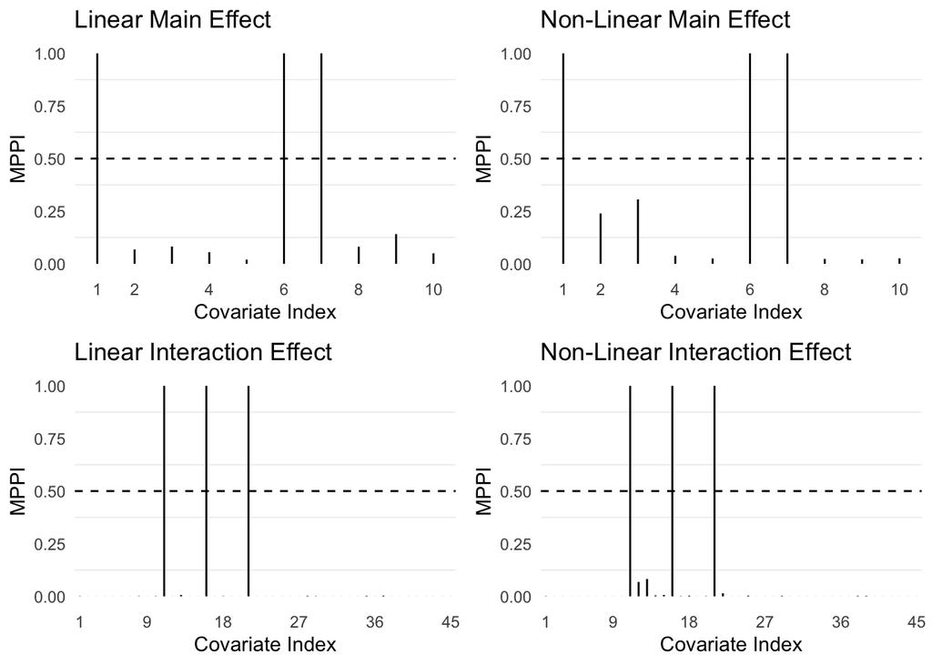

```r
mppi_res <- invent::mppi_plot(out)
```

### Association Plots

The package provides two functions, `plotEffectResponse` and `plotEffectBeta`, which visualize:  
- the association between the response variable and a given covariate (`plotEffectResponse`),  
- the effect of a covariate on a subject-specific regression coefficient (`plotEffectBeta`).

Below we illustrate the main functionalities of both functions.

#### Main Effect Association Plot

We first plot the linear association between covariate 1 and the response variable:

```
## Plotting main effect for variable: 1
```

```
## Linear Main Effects (MPPI >= 0.5):
## - Covariate 1 : 1
## - Covariate 6 : 1
## - Covariate 7 : 1
```

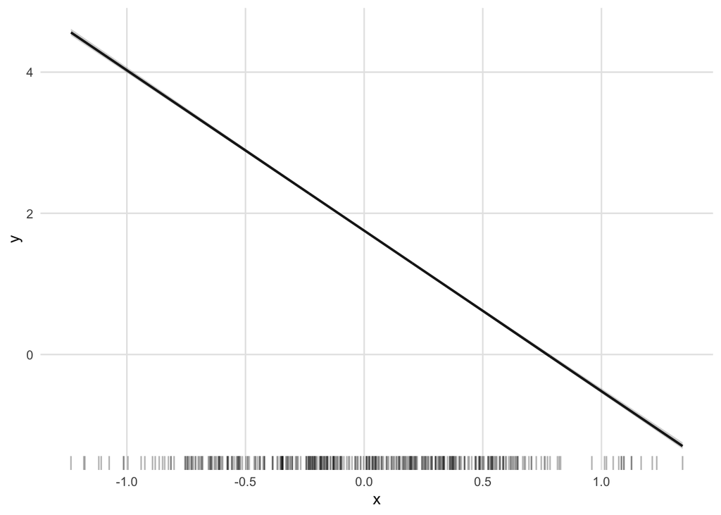

```r
plotEffectResponse(out, 1, type = "linear", effect = "main", xtitle = "x", ytitle = "y")
```

Note that the model output includes only plots for the effects that have been estimated. In other words, not all covariates are associated with the response through linear or non-linear effects.  
We now plot the non-linear effect of covariate 1:

```
## Plotting main effect for variable: 1
```

```
##
## Non-Linear Main Effects (MPPI >= 0.5):
## - Covariate 1 : 1
## - Covariate 6 : 1
## - Covariate 7 : 1
```

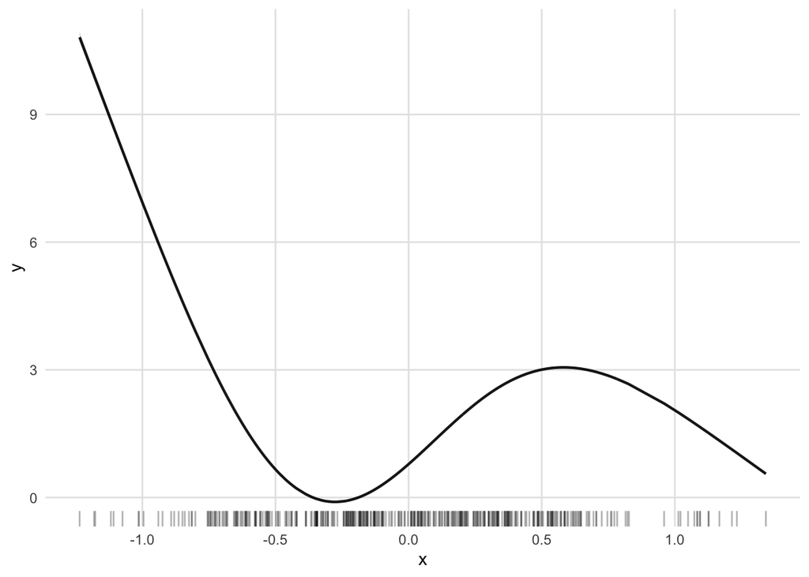

```r
plotEffectResponse(out, 1, type = "nonlinear", effect = "main", xtitle = "x", ytitle = "y")
```

#### Interaction Effect Association Plot

We can also visualize interaction effects. In this case, the function returns a surface plot showing the joint effect of two covariates on the response.  
For example, the following command plots the non-linear interaction between covariates 1 and 6:

```r
plotEffectResponse(out, c(1,6), type = "nonlinear", effect = "interaction",
                   azimut = 60, polar = 20, xtitle = "x1", ytitle = "x2", ztitle = "y")
```

[output not shown]

#### Varying Coefficients Plot

Since the proposed model performs subject-specific inference, we can also visualize how a covariate influences a varying regression coefficient.  
Below we plot the effect of covariate 6 on the linear varying coefficient associated with covariate 7:

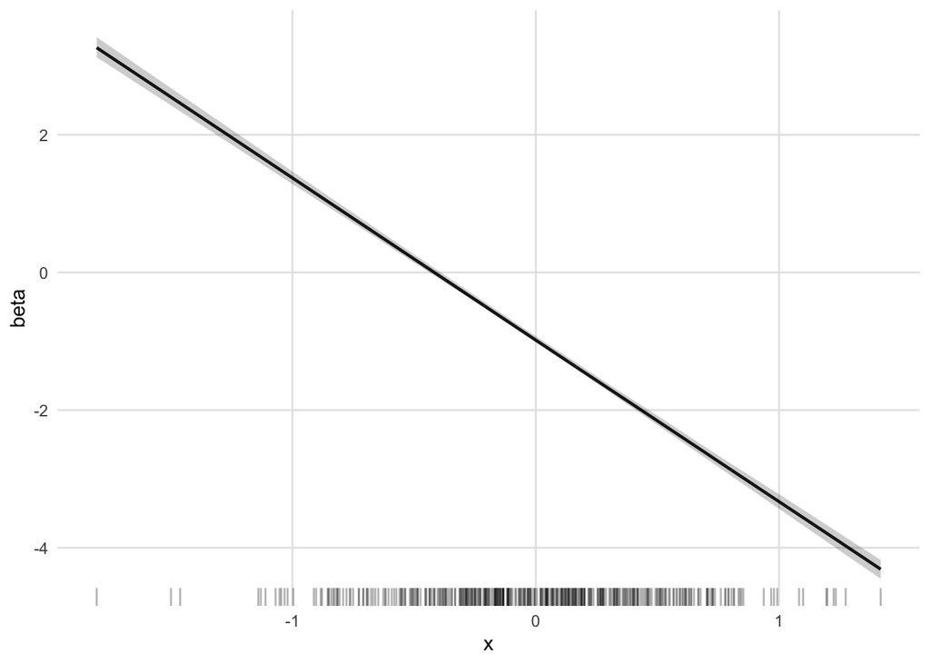

```r
plotEffectBeta(out, 6, 7, type = "linear", xtitle = "x", ytitle = "beta")
```

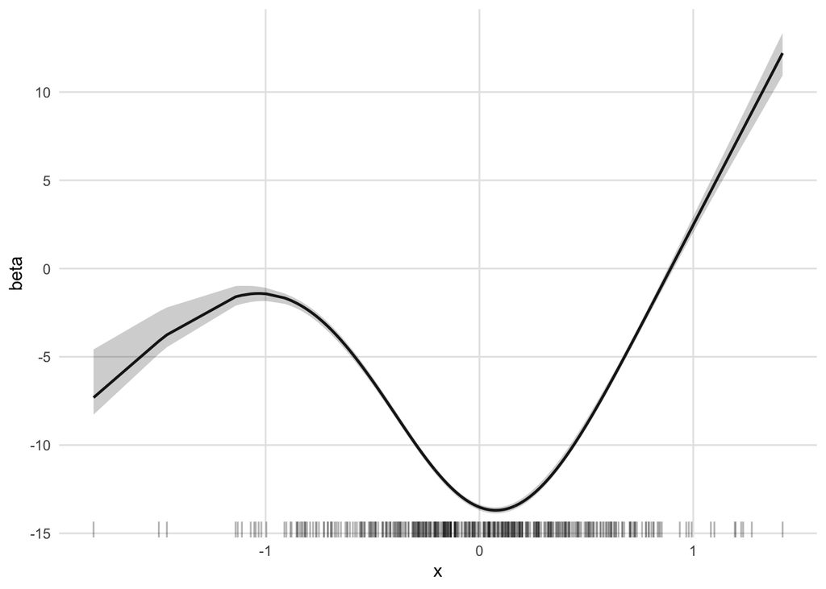

```r
plotEffectBeta(out, 1, 7, type = "nonlinear", xtitle = "x", ytitle = "beta")
```

## `invParMCMC` - Parallel MCMC

### Description

This function implements a parallel Markov Chain Monte Carlo (MCMC) algorithm for INVENT, running multiple chains simultaneously to improve convergence diagnostics. The function automatically handles convergence checking using R-hat statistics and effective sample size (ESS) calculations.

### Usage

```r
invParMCMC(y, x, hyperpar = c(3, 1, 1, 1, 0.00025, 0.4, 1.6, 0.2, 1.8, 0.4, 1.6, 0.2, 1.8),
  mht = c(1.4, 0.8, 1, 0.3, 0.7, 0.4, 4, 2.5),PredOutOfSample = TRUE, rank = 0.95,
  iter = 10000, burnin = iter/2, thin = 5, ha = 2, data = NULL, nchain = 2,
  percValidationSet = 20, seed = 10
)
```

### Arguments

| Argument | Description |
| --- | --- |
| `y` | Response variable vector |
| `x` | Design matrix of predictors |
| `hyperpar` | Vector of hyperparameters (default values shown) |
| `mht` | Metropolis-Hastings tuning parameters (default values shown) |
| `PredOutOfSample` | Logical indicating whether to perform out-of-sample prediction (default: TRUE) |
| `rank` | The percentage of data variability explained by the **P-spline**. (default: 0.95) |
| `iter` | Total number of MCMC iterations (default: 10,000) |
| `burnin` | Number of burn-in iterations (default: iter/2) |
| `thin` | Thinning interval (default: 5) |
| `ha` | Heredity Assumption (default: 2) |
| `data` | Optional data frame containing simulated data |
| `nchain` | Number of parallel chains to run (default: 2) |
| `percValidationSet` | Percentage of data for validation set (default: 20) |
| `seed` | Random seed for reproducibility (default: 10) |

### Output Value

The function returns a list containing:

1. MCMC results from each chain
2. Comprehensive convergence diagnostics including:
   - R-hat statistics for all parameters
   - Effective Sample Size (ESS) calculations
   - Convergence warnings and recommendations

### Convergence Diagnostics

The function automatically checks for convergence using:

1. **R-hat statistics** (Gelman-Rubin diagnostic):
   - Values ≤ 1.10 indicate good convergence
   - Detailed report of problematic parameters
2. **Effective Sample Size (ESS)**:
   - Parameters classified as:
     - Good (ESS ≥ 100)
     - Needs monitoring (50 ≤ ESS < 100)
     - Critical (ESS < 50)

### Examples

#### Basic Usage

```r
invent::invParMCMC(y = y, x = x, iter = iterations, PredOutOfSample = TRUE,
                   burnin = burnin, mht = c(0.8, 0.2, 0.2, 0.6, 0.4, 0.4, 3, 1.4),
                   thin = thin, ha = 2,
                   hyperpar = c(5, 25, 3, 1, 0.00025, 0.4, 1.6, 0.2, 1.8, 0.4, 1.6, 0.2, 1.8),
                   nchain = 3, percValidationSet = 20, data = data, onlyEff = TRUE)
```